# GSODR Data Explore

Kan Dai

# Introduction

- get_GSOD() - this function queries and transfers files from the NCEI’s FTP server, reformats them and returns a tidy data frame in R
- reformat_GSOD() - this function takes individual station files from the local disk and re-formats them returning a tidy data frame in R
- nearest_stations() - this function returns a vector of station IDs that fall within the given radius (kilometres) of a point given as latitude and longitude
- update_station_list() - this function downloads the latest station list from the NCEI’s FTP server updates the package’s internal database of stations and their metadata.
- get_inventory() - this function downloads the latest station inventory information from the NCEI’s FTP server and returns the header information about the latest version as a message in the console and a tidy data frame of the stations’ inventory for each month that data are reported.

For more inforation see the description of the data provided by NCEI, http://www7.ncdc.noaa.gov/CDO/GSOD_DESC.txt.

# Using getGSOD()

```r
library(GSODR)
library(dplyr)
library(ggplot2)
library(ggalt)
library(ggthemes)
library(maps)
```

You can download latest station list information ad update internal database

```r
update_station_list()
```

## Find Stations in China

GSODR provides lists of weather locations and elevation values. Using dplyr, we can find all the stations in China.

```r
load(system.file("extdata", "country_list.rda", package = "GSODR"))
load(system.file("extdata", "isd_history.rda", package = "GSODR"))
station_locations <- left_join(isd_history, country_list, by=c("CTRY" = "FIPS"))
# create data.frame for Australia only
Oz <- subset(station_locations, COUNTRY_NAME == "CHINA")
Oz
```

| USAF | WBAN | STN_NAME | CTRY | STATE | CALL | LAT | LON | ELEV_M | BEGIN | END | STNID | ELEV_M_SRTM_90m | COUNTRY_NAME | iso2c | iso3c |
| --- | --- | --- | --- | --- | --- | --- | --- | --- | --- | --- | --- | --- | --- | --- | --- |
| 450010 | 99999 | CHEUNG CHAU | CH | NA | VHCH | 22.200 | 114.017 | 79.0 | 19730101 | 20020513 | 450010-99999 | 10 | CHINA | CN | CHN |
| 450030 | 99999 | TAI-O | CH | NA | NA | 22.250 | 113.850 | 76.0 | 19770514 | 20020820 | 450030-99999 | 76 | CHINA | CN | CHN |
| 450040 | 99999 | KOWLOON | CH | NA | NA | 22.312 | 114.173 | 66.4 | 19791102 | 20180930 | 450040-99999 | 42 | CHINA | CN | CHN |
| 450050 | 99999 | HONG KONG OBSERVATORY | CH | NA | NA | 22.300 | 114.167 | 62.0 | 19460901 | 20180930 | 450050-99999 | 7 | CHINA | CN | CHN |
| 450060 | 99999 | GREEN ISLAND | CH | NA | NA | 22.283 | 114.117 | 76.0 | 20010707 | 20010707 | 450060-99999 | 76 | CHINA | CN | CHN |
| 450090 | 99999 | TAI MO SHAN | CH | NA | NA | 22.417 | 114.117 | 947.0 | 19471231 | 19560331 | 450090-99999 | 432 | CHINA | CN | CHN |
| 450100 | 99999 | TATE'S CAIRN | CH | NA | NA | 22.367 | 114.217 | 576.0 | 20011226 | 20011226 | 450100-99999 | 281 | CHINA | CN | CHN |
| 450320 | 99999 | TA KWU LING | CH | NA | NA | 22.533 | 114.150 | 13.0 | 19921204 | 20190115 | 450320-99999 | 10 | CHINA | CN | CHN |
| 450330 | 99999 | KAT O | CH | NA | NA | 22.533 | 114.300 | 10.0 | 19921204 | 19990604 | 450330-99999 | 15 | CHINA | CN | CHN |
| 450340 | 99999 | TAI MEI TUK | CH | NA | NA | 22.483 | 114.233 | 53.0 | 19921204 | 19960405 | 450340-99999 | 336 | CHINA | CN | CHN |

[output cut: 990 more lines]

Seletct stations whose name include “BEI”.

```r
subset(Oz, grepl("BEI", STN_NAME))
```

| USAF | WBAN | STN_NAME | CTRY | STATE | CALL | LAT | LON | ELEV_M | BEGIN | END | STNID | ELEV_M_SRTM_90m | COUNTRY_NAME | iso2c | iso3c |
| --- | --- | --- | --- | --- | --- | --- | --- | --- | --- | --- | --- | --- | --- | --- | --- |
| 524410 | 99999 | BEISHAN (MTNS) | CH | NA | NA | 40.717 | 98.617 | 1554.0 | 19730101 | 19900418 | 524410-99999 | 1608 | CHINA | CN | CHN |
| 537981 | 99999 | HANDAN/HEIBEI | CH | NA | ZBHD | 36.533 | 114.433 | 69.8 | 20120116 | 20140715 | 537981-99999 | 69 | CHINA | CN | CHN |
| 545110 | 99999 | BEIJING - CAPITAL INTERNATIONAL AIRPORT | CH | NA | ZBAA | 40.080 | 116.585 | 35.4 | 19451031 | 20190115 | 545110-99999 | 39 | CHINA | CN | CHN |
| 545120 | 99999 | BEI-JING/NAN-YUAN | CH | NA | NA | 39.783 | 116.383 | 40.0 | 19800701 | 20020209 | 545120-99999 | 42 | CHINA | CN | CHN |
| 545130 | 99999 | BEI-JING/TONG-XIAN | CH | NA | NA | 39.817 | 116.700 | 21.0 | 19800703 | 20010725 | 545130-99999 | 23 | CHINA | CN | CHN |
| 570140 | 99999 | BEIDAO | CH | NA | NA | 34.570 | 105.870 | 1086.0 | 20050101 | 20190115 | 570140-99999 | 1090 | CHINA | CN | CHN |
| 575160 | 99999 | JIANGBEI | CH | NA | ZUCK | 29.719 | 106.642 | 416.1 | 19441111 | 20190115 | 575160-99999 | 415 | CHINA | CN | CHN |
| 586060 | 99999 | CHANGBEI INTL | CH | NA | ZSCN | 28.865 | 115.900 | 43.6 | 19560820 | 20190115 | 586060-99999 | 43 | CHINA | CN | CHN |
| 589680 | 99999 | TAIBEI | CH | NA | NA | 25.033 | 121.517 | 9.0 | 19570601 | 20190115 | 589680-99999 | 18 | CHINA | CN | CHN |
| 596440 | 99999 | BEIHAI | CH | NA | NA | 21.483 | 109.100 | 16.0 | 19450811 | 20190115 | 596440-99999 | 8 | CHINA | CN | CHN |

[output cut: 1 more lines]

## Show the distribution of ground-based weather stations

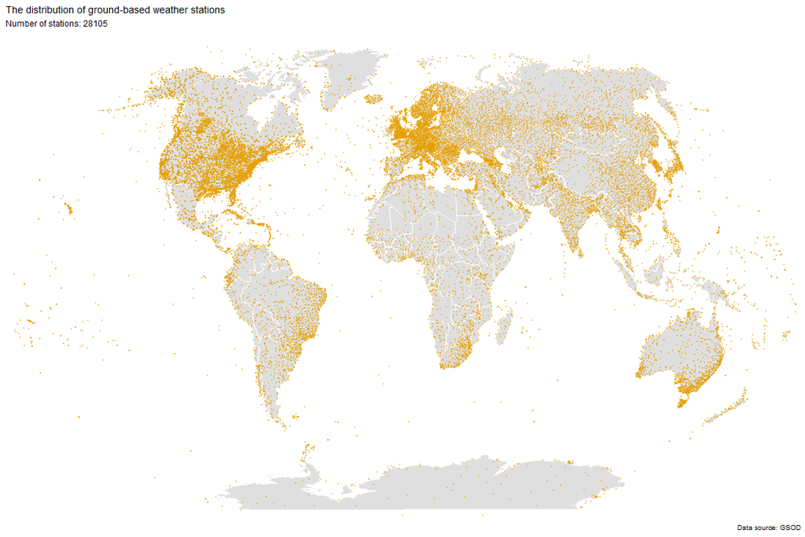

```r
world <- map_data("world")
gg <- ggplot()
gg <- gg + geom_map(data=world, map=world,
                    aes(x=long, y=lat, map_id=region),
                    color="white", fill="#7f7f7f", size=0.05, alpha=0.25)
gg <- gg + geom_point(data=station_locations,
                      aes(x=LON, y=LAT), color="#E69F00", size=0.3, alpha=0.4)
gg <- gg + coord_proj("+proj=wintri")
gg <- gg + labs(title = "The distribution of ground-based weather stations",
                subtitle = paste("Number of stations:", as.character(nrow(station_locations))),
                caption = "Data source: GSOD")
gg <- gg + theme_map()
gg <- gg + theme(strip.background=element_blank())
gg <- gg + theme(legend.position="none")
gg
```